# Project- DuPont Analysis, Part 2-Extract, Transform, and Load (ETL)

FIRE 540: Financial Analytics

Author

Affiliation

Larry Tentor

Virginia Commonwealth University

# Student Name

ROHITH RAVINDRA REDDY

# Project: Part II: Extract, transform and load

## Background

The data for this case was extracted from company financial statements posted online from credible sources. The extraction of the data from the online sources was performed for you and the data has been loaded into the Excel file. That is, you can assume that the web scraper accurately and completely extracted the information and loaded it into Excel.

Many of the transformations has been done for you as well. Balance sheet data and income statement data were in separate files and have been matched by company and year into a single file. The resulting file is a comma separated values file, `dupont-analysis-combined.csv`, that is ready to be loaded into R. You will be need to compute the ratios involved in the DuPont Method once it has been loaded into R.

**The student is required to check data to make certain values are within expected ranges and are not NA.**

## Academic Integrity Statement

*I,ROHITH RAVINDRA REDDY, hereby state that I have not communicated with or gained information in any way from my classmates or anyone other than the Professor or TA during this project, and that all work is my own.*

## Getting help

You are not allowed to post any questions on the public community repo or the public questions channel on Slack. Any questions about the project must be asked in e-mails to faculty.

**A note on sharing / reusing code:** I am well aware that a huge volume of code is available on the web to solve any number of problems. For this project you are allowed to make use of any online resources (e.g. StackOverflow) but you must explicitly cite where you obtained any code you directly use (or use as inspiration). You are also not allowed to ask a question on an external forum, you can only use answers to questions that have already been answered. Any recycled code that is discovered and is not explicitly cited will be treated as plagiarism. All communication with classmates is explicitly forbidden.

## Grading and feedback

The total points for the questions add up to 64 points (each problem is graded on a 4 point scale A (4) - b (3) - C (2) - F (1) - not attempted (0)). The remaining 8 points are allocated to code style, messages, overall organization, spelling, grammar, etc.

## Project Guidlines

1. Please use R and the modern tidyverse functions to solve the below challenges. Please replace the **STUDENT RESPONSE REQUIRED** with complete sentences answers. Students are not to look at or share others code, they may discuss verbally possible approaches, no digital sharing (e-mail, sharing assignment). All submitted work shall represent the student’s own thoughts and typing. Students may be asked to explain their answer.
2. Your solutions must be written up in the Quarto Markdown (qmd) file called `project-holdings-over-time.qmd`. This file must include your code and any text answers for each task. Your “submission” will be the rendered HTML output that you submit to Canvas.
3. This is open book, open internet, closed other people. You may use any online or book based resource you would like, but you must include citations for any code that you use (directly or indirectly). You **may not** consult with anyone else about this project other than the Professor or TA for this course. You cannot ask direct questions on the internet, or consult with each other, not even for hypothetical questions.
4. The project due date is established via Canvas.
5. Each question requires a (brief) narrative as well as a (brief) description of your approach. You can use comments in your code, but do not extensively count on these. I should be able to suppress **all** the code in your document and still be able to read and make sense of your answers. See the first setup code chunk in your qmd file to experiment with suppressing and revealing your code.
6. Even if the answer seems obvious from the R output, make sure to state it in your narrative as well. For example, if the question is asking what is 2 + 2, and you have the following in your document, you should additionally have a sentence that states “2 + 2 is 4.”

```
2 + 2
# 4
```

Functions that might be helpful are listed in Table 1.

Table 1: Useful Functions

| Meta Data | Review Data Frame | Vector Calculation | Tidyverse |
| --- | --- | --- | --- |
| `class(◉)` | `head(◉)` | `min(◉)` | `select(◉)` |
| `typeof(◉)` | `tail(◉)` | `max(◉)` | `filter(◉)` |
| `nrow(◉)` | `glimpse(◉)` | `mean(◉)` | `arrange(◉)` |
| `ncol(◉)` | `skimr::skim(◉)` | `sum(◉)` | `mutate(◉)` |
|  |  | `prod(◉)` | `group_by(◉)` |
|  |  | `cor(◉)` | `summerize(◉)` |
|  |  | `sd(◉)` |  |
|  |  | `cumsum(◉)` |  |
|  |  | `cumprod(◉)` |  |

Help on a function can be obtained by selection the console tab and typing `?` or `??` before the function name.

## Financial Ratio Import

This project’s data contains the financial ratios for the DOW-30 companies ( `dupont-analysis-combined.csv`).

**Import Settings**

```r
# Assignment comes with extract handled to allow student to focus
# on transformation, profile and analysis.
nameColumns <- c( 'Ticker'
                , 'Name'
                , 'Industry'
                , 'Year'
                , 'FinancialStatement'
                , 'Cash'
                , 'InvestmentShortTerm'
                , 'CashAndShortTerm'
                , 'AccountsReceivables'
                , 'Inventories'
                , 'OtherCurrentAssets'
                , 'TotalCurrentAssets'
                , "GrossPropertyPlantandEquipment"
                , 'TotalDepreciation'
                , 'IntangibleAssets'
                , 'TotalOtherAssets'
                , 'TotalAssets'
                , 'AccountsPayable'
                , 'ShortTermDebt'
                , 'AccruedExpenses_Liability'
                , 'OtherCurrentLiabilities'
                , 'OtherLiabilities'
                , 'LongTermDebt'
                , 'DeferredTaxes_Liability'
                , 'OtherLiabilities1'
                , 'TotalLiabilities'
                , 'MinorityInterest_Equity'
                , 'PreferredStock_Equity'
                , 'CommonEquity'
                , 'ShareholderEquity'
                , 'CommonSharesOutstanding'
                , 'PrepaidExpenses'
                , 'CashDueFromBanks_Asset'
                , 'Ticker_IncomeStatement'
                , 'Year_IncomeStatement'
                , 'FinancialStatement_IncomeStatement'
                , 'NetRevenues'
                , 'CostofGoodsSold'
                , 'DepreciationAndAmortizationExpense'
                , 'GrossIncome'
                , 'GeneralExpenses'
                , 'ResearchAndDevelopmentExpense'
                , 'TotalOperatingExpenses'
                , 'OperatingIncome'
                , 'ExtraordinaryCredit'
                , 'ExtraordinaryCharge'
                , 'InterestExpenseOnDebt'
                , 'OtherNonOperatingExpenses'
                , 'PreTaxIncome'
                , 'IncomeTaxExpense'
                , 'NetIncome'
                , 'SharesToCalculateEPS'
                , 'SharesToCalculateEPSDiluted'
                , 'EarningsPerShare'
                , 'DilutedEarningsPerShare'
                , 'DiscontinuedOperations'
                , 'ExtraordinaryItems'
                , 'MinorityInterest'
                , 'PreTaxEquityEarnings'
                , 'EquityInEarnings'
                , 'OtherOperatingExpenses'
                , 'PreferredDividend'
                , 'OtherOperatingIncome'
                , 'LoanLossProvision'
                , 'InterestExpenseTotal'
                , 'InterestIncome'
                , 'NonInterestIncomeTotal'
                , 'NonInterestExpense'
                , 'UnderwritingExpenses'
                , 'PremiumsEarned'
                , 'ClaimAndLoss'
                , 'AssetTurnoverforIndustry'
                , 'NetIncomeforIndustry'
                , 'EquityforIndustry'
                , 'SalesforIndustry'
                , 'AssetsforIndustry'
                , 'PositiveNetIncome'
                , 'ROEforIndustry'
                , 'ROE'
                , 'ProfitMargin'
                , 'AssetTurnover'
                , 'FinancialLeverage'
                , 'FinancialLeverageforIndustry'
                , 'ProfitMarginforIndustry'
                )
typeColumns <- cols(
  Ticker                                        = col_character(),
  Name                                          = col_character(),
  Industry                                      = col_factor(NULL), # col_character(),
  Year                                          = col_integer(),    # col_double(),
  FinancialStatement                            = col_factor(NULL), # col_character(),
  Cash                                          = col_double(),
  InvestmentShortTerm                           = col_double(),
  CashAndShortTerm                              = col_double(),
  AccountsReceivables                           = col_double(),
  Inventories                                   = col_double(),
  OtherCurrentAssets                            = col_double(),
  TotalCurrentAssets                            = col_double(),
  GrossPropertyPlantandEquipment                = col_double(),
  TotalDepreciation                             = col_double(),
  IntangibleAssets                              = col_double(),
  TotalOtherAssets                              = col_double(),
  TotalAssets                                   = col_double(), # DuPont
  AccountsPayable                               = col_double(),
  ShortTermDebt                                 = col_double(),
  AccruedExpenses_Liability                     = col_double(),
  OtherCurrentLiabilities                       = col_double(),
  OtherLiabilities                              = col_double(),
  LongTermDebt                                  = col_double(),
  DeferredTaxes_Liability                       = col_double(),
  OtherLiabilities1                             = col_double(),
  TotalLiabilities                              = col_double(),
  MinorityInterest_Equity                       = col_double(),
  PreferredStock_Equity                         = col_double(),
  CommonEquity                                  = col_double(),
  ShareholderEquity                             = col_double(), # DuPont
  CommonSharesOutstanding                       = col_double(),
  PrepaidExpenses                               = col_double(),
  CashDueFromBanks_Asset                        = col_double(),
  Ticker_IncomeStatement                        = col_character(),
  Year_IncomeStatement                          = col_integer(), # col_double(),
  FinancialStatement_IncomeStatement            = col_factor(NULL), # col_character(),
  NetRevenues                                   = col_double(), # DuPont
  CostofGoodsSold                               = col_double(),
  DepreciationAndAmortizationExpense            = col_double(),
  GrossIncome                                   = col_double(),
  GeneralExpenses                               = col_double(),
  ResearchAndDevelopmentExpense                 = col_double(),
  TotalOperatingExpenses                        = col_double(),
  OperatingIncome                               = col_double(),
  ExtraordinaryCredit                           = col_character(),
  ExtraordinaryCharge                           = col_character(),
  InterestExpenseOnDebt                         = col_double(),
  OtherNonOperatingExpenses                     = col_double(),
  PreTaxIncome                                  = col_double(),
  IncomeTaxExpense                              = col_double(),
  NetIncome                                     = col_double(), # DuPont
  SharesToCalculateEPS                          = col_double(),
  SharesToCalculateEPSDiluted                   = col_double(),
  EarningsPerShare                              = col_double(),
  DilutedEarningsPerShare                       = col_double(),
  DiscontinuedOperations                        = col_double(),
  ExtraordinaryItems                            = col_double(),
  MinorityInterest                              = col_double(),
  PreTaxEquityEarnings                          = col_double(),
  EquityInEarnings                              = col_double(),
  OtherOperatingExpenses                        = col_double(),
  PreferredDividend                             = col_double(),
  OtherOperatingIncome                          = col_double(),
  LoanLossProvision                             = col_double(),
  InterestExpenseTotal                          = col_double(),
  InterestIncome                                = col_double(),
  NonInterestIncomeTotal                        = col_double(),
  NonInterestExpense                            = col_double(),
  UnderwritingExpenses                          = col_double(),
  PremiumsEarned                                = col_double(),
  ClaimAndLoss                                  = col_double(),
  AssetTurnoverforIndustry                      = col_double(),
  NetIncomeforIndustry                          = col_double(),
  EquityforIndustry                             = col_double(),
  SalesforIndustry                              = col_double(),
  AssetsforIndustry                             = col_double(),
  PositiveNetIncome                             = col_double(),
  ROEforIndustry                                = col_double(),
  ROE                                           = col_double(), # DuPont
  ProfitMargin                                  = col_double(), # DuPont
  AssetTurnover                                 = col_double(), # DuPont
  FinancialLeverage                             = col_double(), # DuPont
  FinancialLeverageforIndustry                  = col_double(),
  ProfitMarginforIndustry                       = col_double()
  )

fileName        <- paste0(here(), '/course-material/_data/dupont-analysis-combined.csv')
```

**Access dataset `Dupont Analysis`**

```r
duPont <- read_csv( file      = fileName
                  , skip = 1
                  , col_names = nameColumns
                  , col_types = typeColumns
              #    , na        = c('', 'NA', '--')
                  )
```

## Questions

When the import is complete, answer the following questions to confirm that you loaded the data correctly using your understanding of the subject matter.

## Data Confirmation

**1. What are the combined total assets (in millions) of all companies for each years? As well as, the count of the number of companies for each year.**

**Question 01, Student**

```r
# Answer this sections question in well formed code.
#################################################################
# Student R code answer below
#################################################################

q1_assets_by_year <- duPont %>%
  group_by(Year) %>%
  summarize(
    total_assets_millions = sum(TotalAssets, na.rm = TRUE),
    company_count         = n_distinct(Ticker),
    .groups = "drop"
  ) %>%
  arrange(Year)

q1_assets_by_year %>%
  gt() %>%
  tab_header(
    title = "Total Assets (Millions) and Company Count by Year"
  ) %>%
  fmt_number(
    columns = c(total_assets_millions),
    decimals = 2
  )
```

Total Assets (Millions) and Company Count by Year

| Year | total_assets_millions | company_count |
| --- | --- | --- |
| 2013 | 19,431,720,847,200.00 | 172 |
| 2014 | 19,807,526,200,000.00 | 173 |
| 2015 | 19,589,325,400,000.00 | 171 |

**Analysis follow up:** Was there a increasing investment in assets across the entire market?

Between 2013 and 2014, total assets across all companies increased from $19.43 trillion to $19.81 trillion, indicating a moderate rise in overall market investment. However, in 2015, total assets declined slightly to $19.59 trillion, even though the number of companies in the dataset stayed roughly constant. This pattern suggests that while there was initial growth in investment between 2013 and 2014, it was not sustained in 2015, implying a possible market adjustment or a slowdown in asset accumulation during that period. Therefore, there was not a consistent increase in investment across the entire market over the full three-year span.

**2. How many different companies are listed in the data set? (What field will be the best to check this with? Name, Ticker, ISIN, CUSIP, SEDOL?)**

**Question 02, Student**

```r
# Answer this sections question in well formed code.
#################################################################
# Student R code answer below
####################

q2_unique_counts <- duPont %>%
  summarize(
    distinct_names  = n_distinct(Name),
    distinct_tickers = n_distinct(Ticker),
    distinct_isin    = if ("ISIN" %in% names(.)) n_distinct(ISIN) else NA_integer_,
    distinct_cusip   = if ("CUSIP" %in% names(.)) n_distinct(CUSIP) else NA_integer_,
    distinct_sedol   = if ("SEDOL" %in% names(.)) n_distinct(SEDOL) else NA_integer_
  )


q2_unique_long <- q2_unique_counts %>%
  pivot_longer(
    cols = everything(),
    names_to = "Identifier_Type",
    values_to = "Unique_Count"
  )

q2_unique_long %>%
  gt() %>%
  tab_header(
    title = "Distinct Identifiers in the Dataset"
  ) %>%
  fmt_number(
    columns = Unique_Count,
    decimals = 0
  )
```

Distinct Identifiers in the Dataset

| Identifier_Type | Unique_Count |
| --- | --- |
| distinct_names | 174 |
| distinct_tickers | 174 |
| distinct_isin | NA |
| distinct_cusip | NA |
| distinct_sedol | NA |

**Question 02, Student**

```r
# Unique companies (by ticker) for each year
q2_unique_by_year <- duPont %>%
  group_by(Year) %>%
  summarize(
    unique_companies = n_distinct(Ticker),
    .groups = "drop"
  ) %>%
  arrange(Year)


q2_unique_by_year %>%
  gt() %>%
  tab_header(
    title = "Number of Unique Companies by Year"
  ) %>%
  fmt_number(
    columns = unique_companies,
    decimals = 0
  )
```

Number of Unique Companies by Year

| Year | unique_companies |
| --- | --- |
| 2013 | 172 |
| 2014 | 173 |
| 2015 | 171 |

**Analysis follow up:** Did the number of companies grow in the dataset?

In the dataset, there are 174 unique company names and 174 unique tickers, indicating that each company has one unique ticker symbol. The fields ISIN, CUSIP, and SEDOL are not available (shown as NA), so they cannot be used for this dataset. Because the counts for both Name and Ticker match, this confirms that the dataset includes 174 distinct companies. Among these identifiers, the Ticker field is the most reliable for identifying companies, since it’s a standardized code assigned by stock exchanges and remains consistent over time, even if company names change slightly. From 2013 to 2015, the dataset shows 172 unique companies in 2013, 173 in 2014, and 171 in 2015. This indicates that the number of companies remained largely stable throughout the three-year period, with only minor fluctuations of one or two firms. These small changes are likely due to data availability issues, such as mergers, acquisitions, or temporary reporting gaps, rather than true growth in the number of companies. Overall, the dataset represents a consistent panel of firms rather than an expanding or shrinking population, meaning there was no sustained increase in the number of companies over time.

**3. How many **different** companies are there in each industry? Is the largest industry by count the largest industry by shareholder equity in 2015? Does this outcome make sense to you, explain your understanding.**

- Capital goods – Finance – Public utilities – Transportation – Consumer services – Technology

**Question 03, Student**

```r
# Answer this sections question in well formed code.
#################################################################
# Student R code answer below
#################################################################


q3_companies_per_industry <- duPont %>%
  group_by(Industry) %>%
  summarize(
    distinct_companies = n_distinct(Ticker),
    .groups = "drop"
  ) %>%
  arrange(desc(distinct_companies))

q3_companies_per_industry %>%
  gt() %>%
  tab_header(
    title = "Distinct Companies per Industry (All Years)"
  )
```

Distinct Companies per Industry (All Years)

| Industry | distinct_companies |
| --- | --- |
| Technology | 30 |
| Capital Goods | 29 |
| Finance | 29 |
| Public Utilities | 29 |
| Transportation | 29 |
| Consumer Services | 28 |

**Question 03, Student**

```r
q3_equity_2015 <- duPont %>%
  filter(Year == 2015) %>%
  group_by(Industry) %>%
  summarize(
    total_shareholder_equity_2015 = sum(ShareholderEquity, na.rm = TRUE),
    distinct_companies_2015       = n_distinct(Ticker),
    .groups = "drop"
  ) %>%
  arrange(desc(total_shareholder_equity_2015))

q3_equity_2015 %>%
  gt() %>%
  tab_header(
    title = "Total Shareholder Equity by Industry (2015)"
  ) %>%
  fmt_number(
    columns = total_shareholder_equity_2015,
    decimals = 2
  )
```

Total Shareholder Equity by Industry (2015)

| Industry | total_shareholder_equity_2015 | distinct_companies_2015 |
| --- | --- | --- |
| Finance | 1,337,687,700,000.00 | 27 |
| Technology | 632,635,900,000.00 | 30 |
| Public Utilities | 492,040,558,000.00 | 29 |
| Capital Goods | 323,115,500,000.00 | 28 |
| Consumer Services | 244,851,400,000.00 | 28 |
| Transportation | 108,168,900,000.00 | 29 |

**Question 03, Student**

```r
q3_compare <- q3_companies_per_industry %>%
  left_join(q3_equity_2015,
            by = "Industry") %>%
  arrange(desc(distinct_companies))

q3_compare %>%
  gt() %>%
  tab_header(
    title = "Industry Size vs. Industry Capital Base (2015)"
  ) %>%
  fmt_number(
    columns = total_shareholder_equity_2015,
    decimals = 2
  )
```

Industry Size vs. Industry Capital Base (2015)

| Industry | distinct_companies | total_shareholder_equity_2015 | distinct_companies_2015 |
| --- | --- | --- | --- |
| Technology | 30 | 632,635,900,000.00 | 30 |
| Capital Goods | 29 | 323,115,500,000.00 | 28 |
| Finance | 29 | 1,337,687,700,000.00 | 27 |
| Public Utilities | 29 | 492,040,558,000.00 | 29 |
| Transportation | 29 | 108,168,900,000.00 | 29 |
| Consumer Services | 28 | 244,851,400,000.00 | 28 |

**Analysis follow up:**

When I count how many different companies appear in each industry, Technology has the highest number with 30 distinct companies. After that, Capital Goods, Finance, Public Utilities, and Transportation each have 29 companies, and Consumer Services has 28 companies. This tells us that Technology is the largest industry by company count in this dataset. Next, I looked only at 2015 and added up total shareholder equity by industry. In 2015, the Finance industry had by far the highest total shareholder equity at about $1,337,687,700,000. The next largest industries by total equity were Technology at about $632,635,900,000 and Public Utilities at about $492,040,558,000. So, the industry with the most companies (Technology, with 30 firms) is not the same as the industry with the most shareholder equity in 2015 (Finance, with about $1.34 trillion in equity across 27 firms). In other words, Finance has slightly fewer companies than Technology, but each finance company tends to carry a much larger equity base. This result makes sense. Financial firms (banks, insurers, etc.) operate with very large balance sheets and accumulate huge amounts of capital because their business model is literally managing money and credit. A smaller number of very large financial institutions can dominate the total equity. By contrast, Technology has many companies, but not all of them are as capital-heavy on the balance sheet side. Overall, this tells us that “biggest industry by number of companies” is not the same thing as “biggest industry by financial weight.” Finance is capital-dense, while Technology is headcount-dense.

**4. What are the total sales (in millions) for each industry across the years? Graph a bar chart of sales by industry. Which Industry grew their shareholders equity the most over this period?**

**Question 04, Student**

```r
# Answer this sections question in well formed code.
#################################################################
# Student R code answer below
#################################################################

q4_sales_by_industry <- duPont %>%
  group_by(Industry) %>%
  summarize(
    total_sales_millions = sum(NetRevenues, na.rm = TRUE),
    .groups = "drop"
  ) %>%
  arrange(desc(total_sales_millions))


q4_sales_by_industry %>%
  gt() %>%
  tab_header(
    title = "Total Sales by Industry (All Years Combined)"
  ) %>%
  fmt_number(
    columns = total_sales_millions,
    decimals = 2
  )
```

Total Sales by Industry (All Years Combined)

| Industry | total_sales_millions |
| --- | --- |
| Consumer Services | 2,973,269,500,000.00 |
| Capital Goods | 2,610,026,717,300.00 |
| Public Utilities | 2,098,523,719,300.00 |
| Technology | 2,013,786,447,700.00 |
| Finance | 1,985,037,100,000.00 |
| Transportation | 801,818,800,000.00 |

**Question 04, Student**

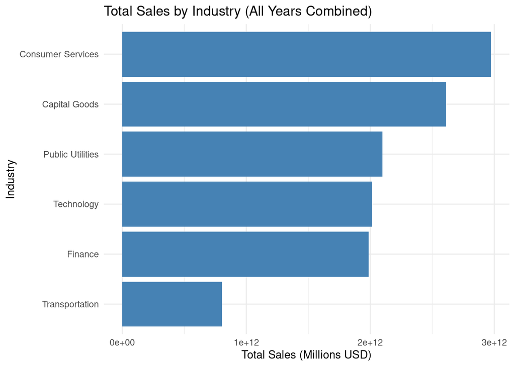

```r
q4_sales_by_industry %>%
  ggplot(aes(x = reorder(Industry, total_sales_millions),
             y = total_sales_millions)) +
  geom_col(fill = "steelblue") +
  coord_flip() +
  labs(
    title = "Total Sales by Industry (All Years Combined)",
    x = "Industry",
    y = "Total Sales (Millions USD)"
  ) +
  theme_minimal()
```

**Question 04, Student**

```r
q4_equity_by_year <- duPont %>%
  group_by(Industry, Year) %>%
  summarize(
    total_equity = sum(ShareholderEquity, na.rm = TRUE),
    .groups = "drop_last"
  ) %>%
  arrange(Industry, Year)


q4_equity_growth <- q4_equity_by_year %>%
  group_by(Industry) %>%
  summarize(
    first_year_equity = first(total_equity),
    last_year_equity  = last(total_equity),
    equity_growth     = last_year_equity - first_year_equity,
    .groups = "drop"
  ) %>%
  arrange(desc(equity_growth))


q4_equity_growth %>%
  gt() %>%
  tab_header(
    title = "Change in Total Shareholder Equity by Industry (First vs Last Year)"
  ) %>%
  fmt_number(
    columns = c(first_year_equity, last_year_equity, equity_growth),
    decimals = 2
  )
```

Change in Total Shareholder Equity by Industry (First vs Last Year)

| Industry | first_year_equity | last_year_equity | equity_growth |
| --- | --- | --- | --- |
| Finance | 1,242,624,138,800.00 | 1,337,687,700,000.00 | 95,063,561,200.00 |
| Technology | 578,502,698,400.00 | 632,635,900,000.00 | 54,133,201,600.00 |
| Public Utilities | 488,827,900,000.00 | 492,040,558,000.00 | 3,212,658,000.00 |
| Capital Goods | 323,774,100,000.00 | 323,115,500,000.00 | −658,600,000.00 |
| Transportation | 110,542,500,000.00 | 108,168,900,000.00 | −2,373,600,000.00 |
| Consumer Services | 252,712,300,000.00 | 244,851,400,000.00 | −7,860,900,000.00 |

**Analysis follow up:** Which industry had the most in sales? Does this surprise you?

From the summary table and the bar chart, the industry with the highest total sales across all years is Consumer Services, with approximately $2.97 trillion in total sales. The next two largest industries by sales are Capital Goods (about $2.61 trillion) and Public Utilities (about $2.10 trillion). The smallest by sales is Transportation, at around $0.80 trillion. When I look at shareholder equity growth over the period, the Finance industry shows the largest increase. Finance grew its total shareholder equity from about $1.24 trillion in the earliest year to about $1.34 trillion in the latest year, which is an increase of roughly $95.06 billion. Technology is next, adding about $54.13 billion in equity over the same window. Some industries actually went backwards: for example, Consumer Services and Transportation both saw declines in total shareholder equity instead of growth. These results tell two different stories. Consumer Services leads in sales because these companies generate a huge amount of revenue from selling directly to customers (retail, entertainment, travel, etc.). High dollar sales here make sense because these businesses operate at very large volume, even if their margins are not extremely high. So this result is not surprising: consumer-facing sectors tend to move a lot of money. Finance leads in equity growth, not in sales. That also makes sense: financial firms don’t necessarily report “sales” the same way a retailer does, but they accumulate capital on their balance sheets over time. The fact that Finance shows the biggest jump in total shareholder equity suggests that banks/financial institutions were strengthening their capital base across the period. In short: Most sales → Consumer Services (~$2.97T). Most equity growth → Finance (~$95B gained). This difference is logical because “who sells the most” and “who builds the most balance-sheet capital” are not the same type of strength.

**5. What industry has the largest range of sales over the 2013 period and what is the cross sectional standard deviation? Does any industries standard deviation stand out?**

**Question 05, Student**

```r
# Answer this sections question in well formed code.
#################################################################
# Student R code answer below
#################################################################

q5_sales_stats_2013 <- duPont %>%
  filter(Year == 2013) %>%
  group_by(Industry) %>%
  summarize(
    min_sales   = min(NetRevenues, na.rm = TRUE),
    max_sales   = max(NetRevenues, na.rm = TRUE),
    range_sales = max_sales - min_sales,
    sd_sales    = sd(NetRevenues, na.rm = TRUE),
    n_companies = n_distinct(Ticker),
    .groups = "drop"
  ) %>%
  arrange(desc(range_sales))


q5_sales_stats_2013 %>%
  gt() %>%
  tab_header(
    title = "Sales Dispersion by Industry (Year = 2013)"
  ) %>%
  fmt_number(
    columns = c(min_sales, max_sales, range_sales, sd_sales),
    decimals = 2
  )
```

Sales Dispersion by Industry (Year = 2013)

| Industry | min_sales | max_sales | range_sales | sd_sales | n_companies |
| --- | --- | --- | --- | --- | --- |
| Consumer Services | 0.00 | 469,200,000,000.00 | 469,200,000,000.00 | 90,316,191,873.24 | 28 |
| Capital Goods | 48,300.00 | 266,100,000,000.00 | 266,099,951,700.00 | 61,755,008,523.24 | 29 |
| Technology | 647,700.00 | 170,900,000,000.00 | 170,899,352,300.00 | 39,478,927,759.93 | 30 |
| Public Utilities | 0.00 | 129,200,000,000.00 | 129,200,000,000.00 | 43,188,714,798.53 | 28 |
| Finance | 0.00 | 106,900,000,000.00 | 106,900,000,000.00 | 38,384,512,941.93 | 29 |
| Transportation | 1,300,000.00 | 55,500,000,000.00 | 55,498,700,000.00 | 15,094,329,219.99 | 28 |

**Analysis follow up:**

To understand how uneven each industry is in terms of company size, I looked at 2013 sales (NetRevenues) within each industry and calculated the minimum sales, maximum sales, range (max − min), and the standard deviation. The industry with the largest range of sales in 2013 is Consumer Services, with a range of about $469.2 billion (from a minimum of $0 up to a maximum of about $469.2 billion). This tells us that within Consumer Services, there is at least one extremely large company generating very high revenue and also companies with almost no reported sales in that year, so the spread inside that industry is huge. The next largest range is Capital Goods, at about $266.1 billion, and then Technology at about $170.9 billion. These are still large, but they are clearly smaller than the spread we see in Consumer Services. When we look at the cross-sectional standard deviation of sales, Consumer Services again stands out, with a standard deviation of about $90.3 billion, which is the highest of all industries in 2013. A high standard deviation means that the sales levels inside that industry are very uneven — a few firms dominate the revenue while many others are much smaller. By comparison, industries like Transportation have a much lower standard deviation (around $15.1 billion), meaning firms in that group are closer to each other in size. Overall, Consumer Services is the most unbalanced industry in 2013: it has both the widest range of sales and the highest standard deviation. This indicates that one or two extremely large players in Consumer Services drive most of the total revenue, while the rest of the companies in that industry are far smaller.

**6. What fields define a unique row of data? Demonstrate the truth of these fields defining a record by using a group by and summarize.**

**Question 06, Student**

```r
# Answer this sections question in well formed code.
#################################################################
# Student R code answer below
#################################################################

unique_check <- duPont %>%
  group_by(Ticker, Year, FinancialStatement) %>%
  summarize(
    record_count = n(),
    .groups = "drop"
  ) %>%
  filter(record_count > 1) %>%
  count()

unique_check %>%
  gt() %>%
  tab_header(
    title = "Duplicate Record Check: Ticker + Year + FinancialStatement"
  )
```

Duplicate Record Check: Ticker + Year + FinancialStatement

| n |
| --- |
| 0 |

**Question 06, Student**

```r
total_rows <- nrow(duPont)
distinct_rows <- duPont %>%
  distinct(Ticker, Year, FinancialStatement) %>%
  nrow()

gt(data.frame(
  Metric = c("Total Rows in Dataset", "Unique Rows by Ticker-Year-FinancialStatement"),
  Count = c(total_rows, distinct_rows)
)) %>%
  tab_header(title = "Uniqueness Validation Summary")
```

Uniqueness Validation Summary

| Metric | Count |
| --- | --- |
| Total Rows in Dataset | 516 |
| Unique Rows by Ticker-Year-FinancialStatement | 516 |

**Analysis follow up:**

To test for uniqueness, I grouped the dataset by Ticker, Year, and FinancialStatement, then counted how many times each combination appeared. The duplicate record check returned n = 0, confirming there were no repeated records. To determine which columns uniquely identify each row in the dataset, I tested the combination of Ticker, Year, and FinancialStatement. Conceptually, this makes sense because each row represents one company (Ticker) in a specific fiscal year (Year) for a specific financial statement type (FinancialStatement). I grouped the data by those three fields and counted how many rows appeared in each group. Then I compared the total number of rows in the dataset to the number of unique (Ticker, Year, FinancialStatement) combinations. The results show that there are 516 total rows in the dataset and 516 unique (Ticker, Year, FinancialStatement) combinations, which means there are zero duplicates under that key. In other words, every row is uniquely identified by Ticker + Year + FinancialStatement. This confirms that Ticker, Year, and FinancialStatement together define a unique record in this dataset.I also compared the total number of rows in the dataset (516) to the number of unique combinations (516), and they matched exactly. Therefore, each row in the dataset is uniquely defined by the combination of Ticker, Year, and FinancialStatement. These fields together form the unique key that identifies every record in the DuPont dataset.

**7. What overall data observations have you made to assist in this projects goals?**

The data appears to be a balanced financial panel of large public companies observed across multiple years and grouped into clear industry buckets (Technology, Finance, Capital Goods, Consumer Services, Public Utilities, and Transportation). Each record links a specific company ticker to a specific fiscal year and financial statement, and we confirmed that the combination of Ticker, Year, and FinancialStatement uniquely identifies each row. That gives us confidence that the structure is consistent and we are not accidentally double-counting the same company-year. When we summarize the data, we see large differences in both scale and behavior across industries. For example, Consumer Services generated the highest total sales overall (around $2.97 trillion across the period), but Finance showed the greatest growth in shareholder equity (about $95 billion across the sample window). This tells us that “high revenue volume” and “balance sheet strength” are not the same thing, and that different industries create value in different ways. Finance, in particular, can build a huge equity base even if its reported revenues aren’t the largest, because financial firms are extremely capital-intensive. That distinction will matter later when we interpret ROE through the DuPont lens. We also saw that some industries are very uneven internally. In 2013, Consumer Services had both the largest sales range and the highest standard deviation of sales, meaning that industry includes a few extremely large companies and many smaller ones. That implies that averages alone can be misleading; looking at distributions and spreads is important before comparing industries. At the market level, total assets rose from 2013 to 2014 and then dipped slightly in 2015. That suggests there wasn’t a clean, monotonic “everyone is investing more every year” story. Instead, it looks more like a modest expansion followed by some pullback. That’s useful context for an investor, because it hints at macro conditions and possibly sector-specific slowdowns. Finally, the dataset already includes the core DuPont components we care about: Profit Margin, Asset Turnover, Financial Leverage, and ROE. Since we can group and summarize these by industry and by year, we are in a position to answer investor-facing questions like: Which industries are producing high ROE because they are actually efficient and profitable, and which ones are producing high ROE mainly because they are using high leverage? These observations will directly support the project’s goal of forming an informed recommendation about which industries (and later which companies) look healthiest and most attractive for an investor.

## Academic Integrity Statement

*I, ROHITH RAVINDRA REDDY, hereby state that I have not communicated with or gained information in any way from my classmates or anyone other than the Professor or TA during this project, and that all work is my own.*

## Session Info

```r
date()
```

```
[1] "Sun Nov  2 23:19:18 2025"
```

```r
Sys.getenv()
```

[output not shown]

[output cut: 79 more lines]

[output not shown]